# QDA Lab 1 Part 2 A solution

Dr Isabel Sasssoon

This is a solution to the independent practice in the first lab . In R there are many ways of obtaining the same information.

This data set is available in the *{ggplot}* library that was already loaded earlier in this session.

If you have not loaded ggplot2 then the code is below:

```r
library(ggplot2)
```

1. Run the code below to see the description of the diamond data and its contents.

```r
help("diamonds")
```

```
## starting httpd help server ... done
```

Now the data can be accessed, using head(data) returns the first few rows of data.

```r
head(diamonds)
```

| carat | cut | color | clarity | depth | table | price | x | y | z |
| --- | --- | --- | --- | --- | --- | --- | --- | --- | --- |
| 0.23 | Ideal | E | SI2 | 61.5 | 55 | 326 | 3.95 | 3.98 | 2.43 |
| 0.21 | Premium | E | SI1 | 59.8 | 61 | 326 | 3.89 | 3.84 | 2.31 |
| 0.23 | Good | E | VS1 | 56.9 | 65 | 327 | 4.05 | 4.07 | 2.31 |
| 0.29 | Premium | I | VS2 | 62.4 | 58 | 334 | 4.20 | 4.23 | 2.63 |
| 0.31 | Good | J | SI2 | 63.3 | 58 | 335 | 4.34 | 4.35 | 2.75 |
| 0.24 | Very Good | J | VVS2 | 62.8 | 57 | 336 | 3.94 | 3.96 | 2.48 |

2. Check that the data set *diamonds* does indeed contain the columns as in the help

```r
names(diamonds)
```

```
##  [1] "carat"   "cut"     "color"   "clarity" "depth"   "table"   "price"
##  [8] "x"       "y"       "z"
```

or to have more details on the columns:

```r
str(diamonds)
```

```
## tibble [53,940 × 10] (S3: tbl_df/tbl/data.frame)
##  $ carat  : num [1:53940] 0.23 0.21 0.23 0.29 0.31 0.24 0.24 0.26 0.22 0.23 ...
##  $ cut    : Ord.factor w/ 5 levels "Fair"<"Good"<..: 5 4 2 4 2 3 3 3 1 3 ...
##  $ color  : Ord.factor w/ 7 levels "D"<"E"<"F"<"G"<..: 2 2 2 6 7 7 6 5 2 5 ...
##  $ clarity: Ord.factor w/ 8 levels "I1"<"SI2"<"SI1"<..: 2 3 5 4 2 6 7 3 4 5 ...
##  $ depth  : num [1:53940] 61.5 59.8 56.9 62.4 63.3 62.8 62.3 61.9 65.1 59.4 ...
##  $ table  : num [1:53940] 55 61 65 58 58 57 57 55 61 61 ...
##  $ price  : int [1:53940] 326 326 327 334 335 336 336 337 337 338 ...
##  $ x      : num [1:53940] 3.95 3.89 4.05 4.2 4.34 3.94 3.95 4.07 3.87 4 ...
##  $ y      : num [1:53940] 3.98 3.84 4.07 4.23 4.35 3.96 3.98 4.11 3.78 4.05 ...
##  $ z      : num [1:53940] 2.43 2.31 2.31 2.63 2.75 2.48 2.47 2.53 2.49 2.39 ...
```

3. The help description of the data set has the ranges for the variables in this data set. Check that this is the case in the data. Are there any variables out of range?

The ranges for the numerical variables can be obtained using the summary function. There are other ways.

To run summary on one variable only use the $ to specify the column.

```r
summary(diamonds$price)
```

```
##    Min. 1st Qu.  Median    Mean 3rd Qu.    Max.
##     326     950    2401    3933    5324   18823
```

The code above can be repeated for each of the variables in turn or use summary on all the data frame.

```r
summary(diamonds)
```

```
##      carat               cut        color        clarity          depth
##  Min.   :0.2000   Fair     : 1610   D: 6775   SI1    :13065   Min.   :43.00
##  1st Qu.:0.4000   Good     : 4906   E: 9797   VS2    :12258   1st Qu.:61.00
##  Median :0.7000   Very Good:12082   F: 9542   SI2    : 9194   Median :61.80
##  Mean   :0.7979   Premium  :13791   G:11292   VS1    : 8171   Mean   :61.75
##  3rd Qu.:1.0400   Ideal    :21551   H: 8304   VVS2   : 5066   3rd Qu.:62.50
##  Max.   :5.0100                     I: 5422   VVS1   : 3655   Max.   :79.00
##                                     J: 2808   (Other): 2531
##      table           price             x                y
##  Min.   :43.00   Min.   :  326   Min.   : 0.000   Min.   : 0.000
##  1st Qu.:56.00   1st Qu.:  950   1st Qu.: 4.710   1st Qu.: 4.720
##  Median :57.00   Median : 2401   Median : 5.700   Median : 5.710
##  Mean   :57.46   Mean   : 3933   Mean   : 5.731   Mean   : 5.735
##  3rd Qu.:59.00   3rd Qu.: 5324   3rd Qu.: 6.540   3rd Qu.: 6.540
##  Max.   :95.00   Max.   :18823   Max.   :10.740   Max.   :58.900
##
##        z
##  Min.   : 0.000
##  1st Qu.: 2.910
##  Median : 3.530
##  Mean   : 3.539
##  3rd Qu.: 4.040
##  Max.   :31.800
##
```

It seems like there is an inconsistency in column z, the table shows a range of 0-3.18 but the actual data tells a different story. *Always check what is in the data*

4. How many levels (or different categories) are in the column labelled *cut*?

The levels of a categorical variable can be obtained using a table function.

```r
table(diamonds$cut)
```

```
##
##      Fair      Good Very Good   Premium     Ideal
##      1610      4906     12082     13791     21551
```

The variable cut is categorical and has 5 levels or values.

5. Generate a numerical summary for each variable in the data set - take care to use the appropriate technique for each different variable type.

The numerical summary can be done as in (c), but in general for numerical attributes a summary works well, a table for categorical variables.

```r
summary(diamonds)
```

```
##      carat               cut        color        clarity          depth
##  Min.   :0.2000   Fair     : 1610   D: 6775   SI1    :13065   Min.   :43.00
##  1st Qu.:0.4000   Good     : 4906   E: 9797   VS2    :12258   1st Qu.:61.00
##  Median :0.7000   Very Good:12082   F: 9542   SI2    : 9194   Median :61.80
##  Mean   :0.7979   Premium  :13791   G:11292   VS1    : 8171   Mean   :61.75
##  3rd Qu.:1.0400   Ideal    :21551   H: 8304   VVS2   : 5066   3rd Qu.:62.50
##  Max.   :5.0100                     I: 5422   VVS1   : 3655   Max.   :79.00
##                                     J: 2808   (Other): 2531
##      table           price             x                y
##  Min.   :43.00   Min.   :  326   Min.   : 0.000   Min.   : 0.000
##  1st Qu.:56.00   1st Qu.:  950   1st Qu.: 4.710   1st Qu.: 4.720
##  Median :57.00   Median : 2401   Median : 5.700   Median : 5.710
##  Mean   :57.46   Mean   : 3933   Mean   : 5.731   Mean   : 5.735
##  3rd Qu.:59.00   3rd Qu.: 5324   3rd Qu.: 6.540   3rd Qu.: 6.540
##  Max.   :95.00   Max.   :18823   Max.   :10.740   Max.   :58.900
##
##        z
##  Min.   : 0.000
##  1st Qu.: 2.910
##  Median : 3.530
##  Mean   : 3.539
##  3rd Qu.: 4.040
##  Max.   :31.800
##
```

6. For each variable generate a plot, use different options and make sure the plots are labelled, and suitable to the type of variable.

For example for a numerical attribute we would look at a histogram

Firstly we can use the graph function in base R (this does not need a separate library)

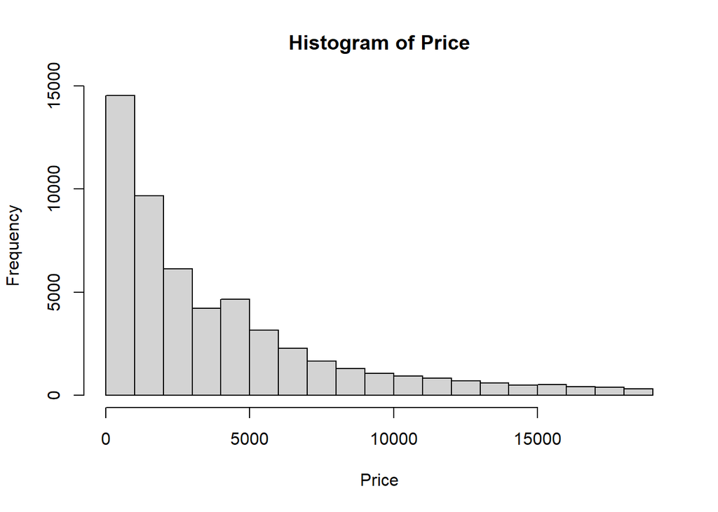

```r
hist(diamonds$price, main=paste("Histogram of Price"), xlab="Price")
```

(optional) another way to plot this can be achieved using ggplot library:

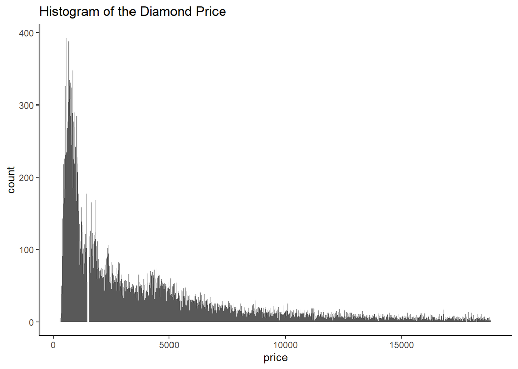

```r
ggplot(diamonds, aes(x=price)) + geom_histogram(binwidth = 10) +
  theme_classic() + ggtitle("Histogram of the Diamond Price")
```

The same code can be used for the remaining continuous variables.

For the categorical variables we can use this shortcut that uses a table function to then make a plot.

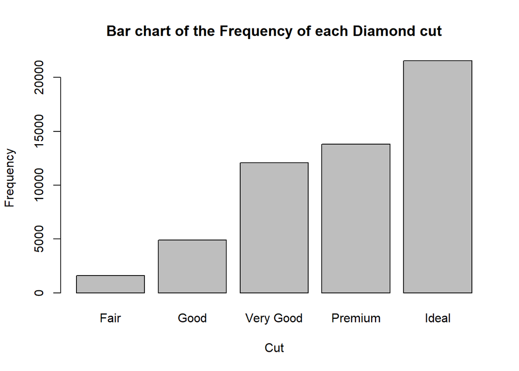

```r
barplot(table(diamonds$cut), xlab = "Cut", ylab = "Frequency", main="Bar chart of the Frequency of each Diamond cut")
```

(Optional) If we want to use the GGplot library then the following ggplot syntax can be used:

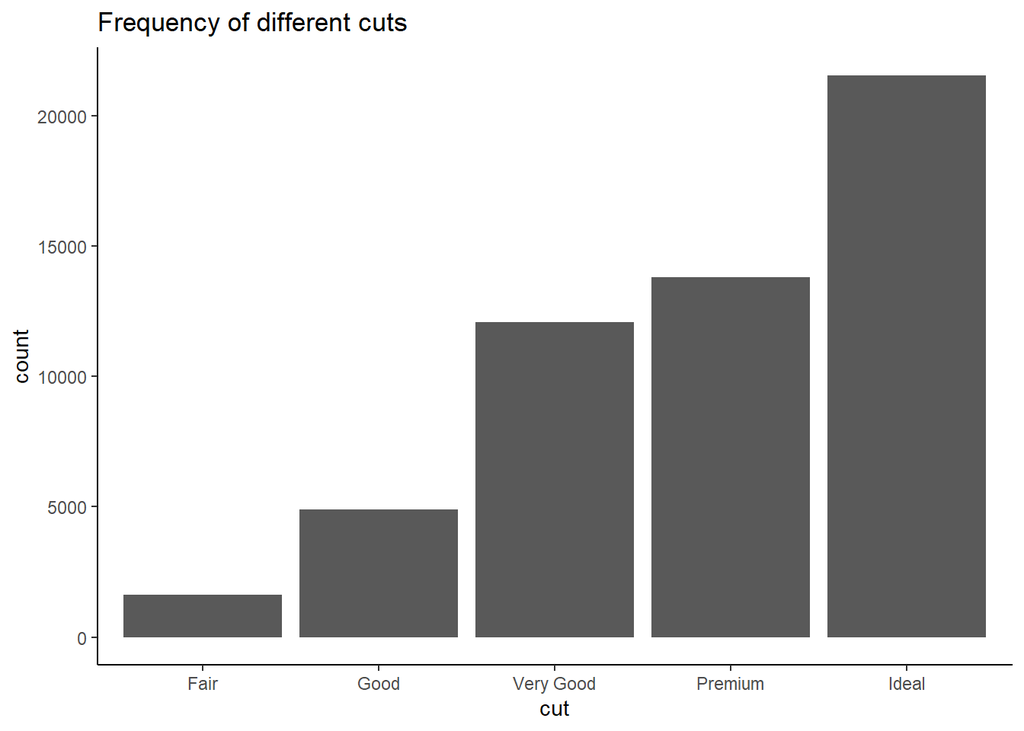

```r
ggplot(diamonds, aes(cut)) + geom_bar() + ggtitle("Frequency of different cuts") +theme_classic()
```

Other options include pie charts.

7. Explore the graphing of one categorical against one of the continuous variables in this data.

This is a good opportunity to use a box plot.

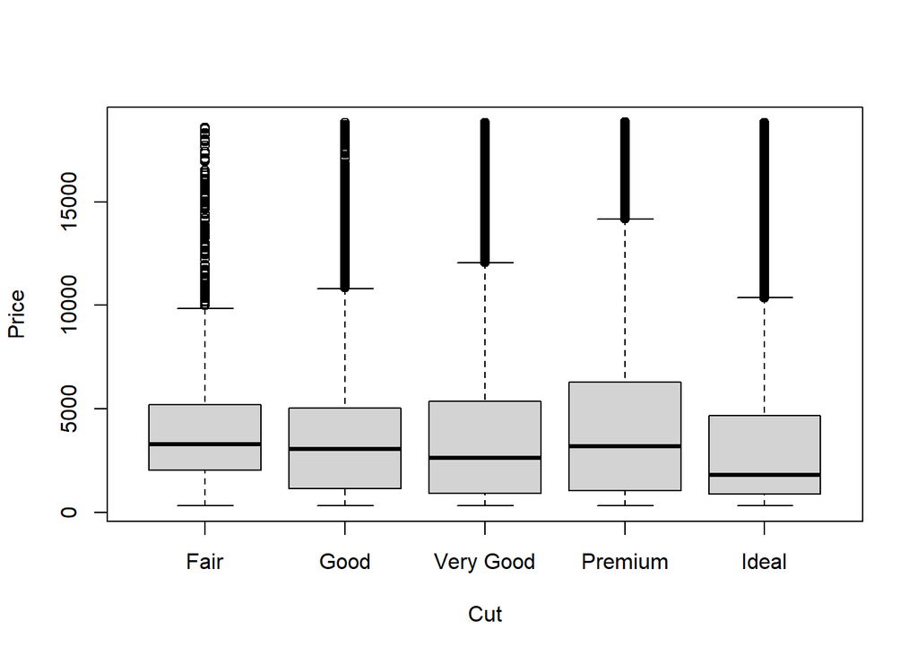

```r
boxplot(diamonds$price~diamonds$cut, xlab="Cut", ylab="Price")
```

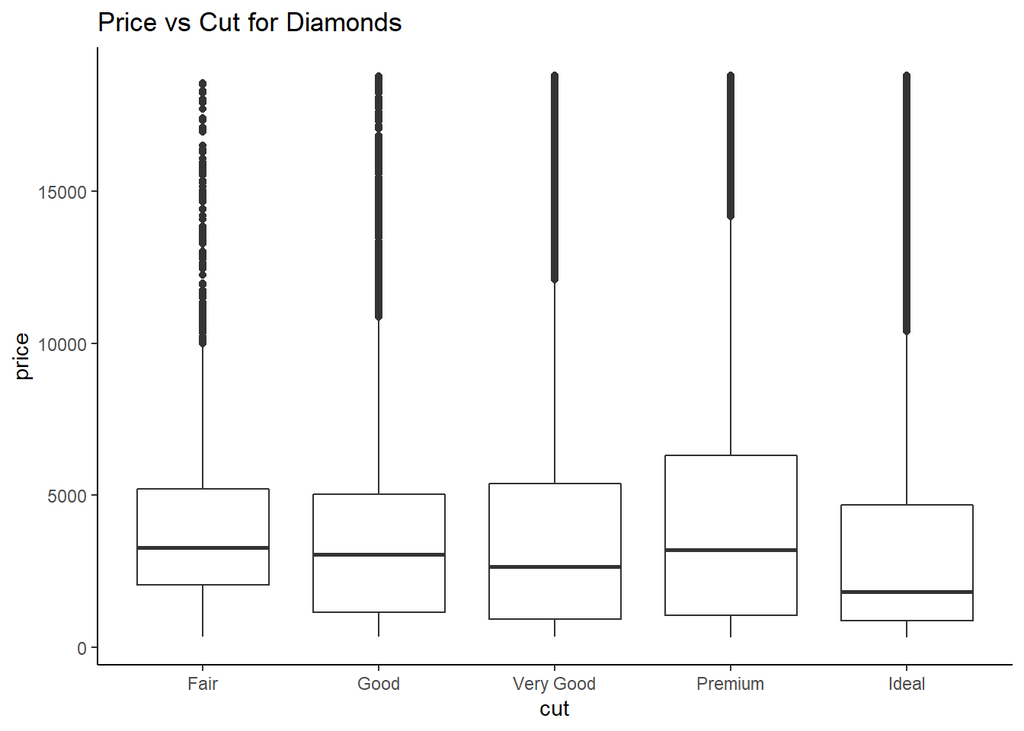

```r
ggplot(diamonds, aes(x=cut, y=price)) + geom_boxplot() +
  theme_classic() + ggtitle("Price vs Cut for Diamonds")
```

You can try the same changing the variable on the y axis.